# Data Science And Statistical Modelling In Space And Time Coursework

Giuseppe Lovascio

2024-05-06

```r
library(lubridate)
library(dplyr)
library(readxl)
library(ggplot2)
library(knitr)
library(kableExtra)
library(geoR)
library(fields)
library(EgoCor)
library(rnaturalearth)
library(sf)
library(rnaturalearthdata)
library(knitr)
library(readr)
library(readxl)
library(ggplot2)
library(plotly)
library(TSA)
library(TSstudio)
library(forecast)
library(tseries)
library(ggplot2)
library(dplyr)
library(tibble)
library(tidyr)
library(BETS)
library(tsibble)
library(lubridate)
library(dlm)
library(readxl)
library(kableExtra)
library(sf)
library(tmap)
library(xts)
library(hydroTSM)
library(maps)
library(astsa)
library(rnaturalearthhires)
library(rnaturalearth)
library(kernlab)
```

# Question 1

## 1.A

We convert the initial dataset into geodata object for better visualisation, since the dataset contained coordinates for the stations.

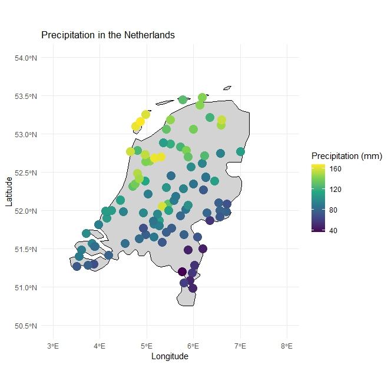

**Fig 1: Tot Precipitations(mm) in September 2019 Netherlands Stations**

There is a fairly linear increase in precipitation with the increase in latitude, i.e. going further north in the map of the Dutch stations. This element is important and will have to be considered when fitting models that attempt to model this variable for the Dutch stations.

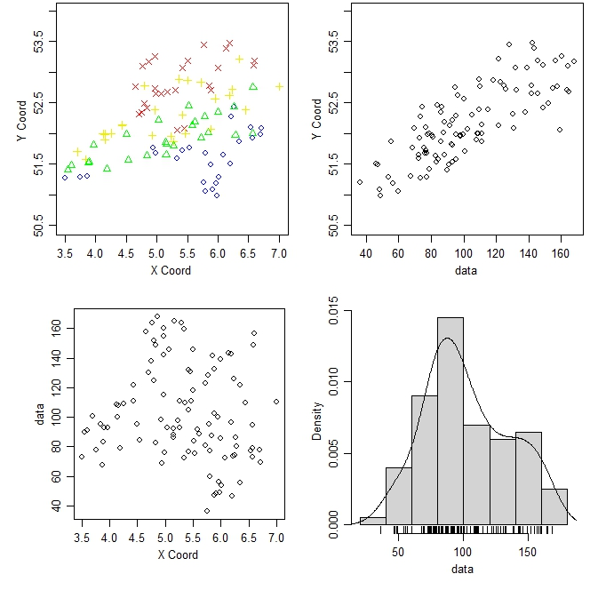

**Fig 2: Overview of Characteristics of Dataset**

Figure 2 confirms the positive linear relationship between precipitations and latitude. The precipitations totals don’t appear to be normally distributed.

## 1.B

We select 5 stations at random and remove them from the training dataset, that we will use for fitting the models.

This step will be also useful when validating our models, since we will have residuals from the predictions to compare to the actual values and the models will be less biased.

Of course fitting the model using stations that might present different spatial characteristics, that is longitude and latitude, with respect to the stations we want to predict for can impact the predictions themselves, since distance is considered in both the variogram and Gaussian Process based on Maximum likelihood estimation.

```r
# select 5 stations at random from original dataset
set.seed(123)
selected_stations <- sample_n(precip_data, 5)
#  stations to remove from train dataset
print(selected_stations$station_name)
```

```
## [1] "RILLAND"        "SCHELLINGWOUDE" "EELDE-1"        "GIERSBERGEN"
## [5] "MAKKUM"
```

## 1.C

The first method to model the data we will be using is Kriging based on variograms.

We obtain the sample variogram to the data.

```r
sample_vario_precip <- variog(precip_data_train_geo, option = 'bin')
```

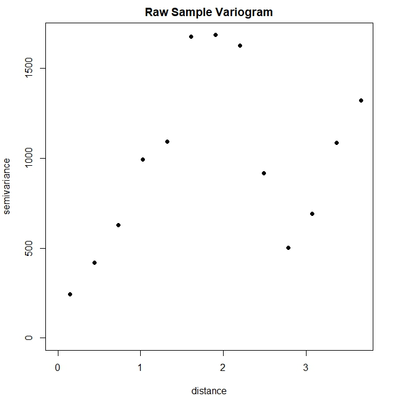

**Fig 3: Raw Sample Variogram Precipitations Data**

From the raw sample variogram we see that the partial sill starts to decline at higher distances, since there are fewer pairs of points in the bins.

But we know from geostatistical principles that the variance should increase as distance increases, therefore the variogram has to be modified.

We will set a maximum distance equal to 1.75, which is approximately the distance where the variance starts to decrease.

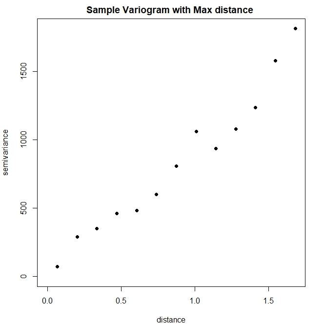

**Fig 4: Sample Variogram with Defined Maximum Distance**

We see indeed how the structure is now correct, with variances increasing with increase in distance between stations.

We also see from figure 4 the presence of a small nugget effect, which is the value of the variogram at zero distance. We will therefore set a nugget in the models we will estimate. This assumption can reduce slightly the correlation between adjacent stations.

By inserting a nugget we want to account for small scale variability, since two observations sampled closely will not always have the same value.

Presence of a nugget means that any two observations sampled arbitrarily closely will not necessarily have the same value.

Before fitting the models, we define the initial values to use in the optimization.

These are the partial sill, that is the difference between sill and nugget, and since for our case the nugget will be small it will be basically considered equal to the sill.From figure 4 we can see how this value can be considered to be 1750. Then we also set the initial value for range, which is the distance where the variogram starts to flatten out. This is an important element, since stations farther from the range will not present spatial autocorrelation.

We set the initial value for the range as 1.75.

```r
ini_values_krig<-c(1750,1.75)
```

We fit a Parametric model, based on the variogram.

In the first model we define the nugget as equal to 2, and we leave the covariance function as the standard Matern with smoothness parameter kappa=0.5, so that we can have an initial idea of the fitting to the actual data and variogram.

```
## variog: computing omnidirectional variogram
```

```r
  krig_1 <- variofit(sample_vario_1,ini.cov.pars = ini_values_krig,fix.nugget=T,nugget=2)

estimated_parameters <- summary(krig_1)$estimated.pars
estimated_parameters
```

The parameters estimated are :

[output not shown]

In particular here we have set the nugget, τ², as fixed, β, is constant, while ϕ, the correlation range and σ², the partial sill or variance, have been directly estimated by the fitted model.

We try to improve the fit by changing covariance models.

First we use a spherical covariance function, leaving all the other assumptions and estimated parameters equal.

```r
krig_2 <- variofit(sample_vario_1,ini.cov.pars = ini_values_krig,fix.nugget=T,nugget=2,cov.model = "spherical")
```

Then we fit another model with covariance function being “power”, and smoothness parameter kappa equal to 0.5.

```r
krig_3 <- variofit(sample_vario_1, nugget = 2, cov.model = "power", fix.nugget = TRUE, ini.cov.pars = ini_values_krig,kappa=0.5)
```

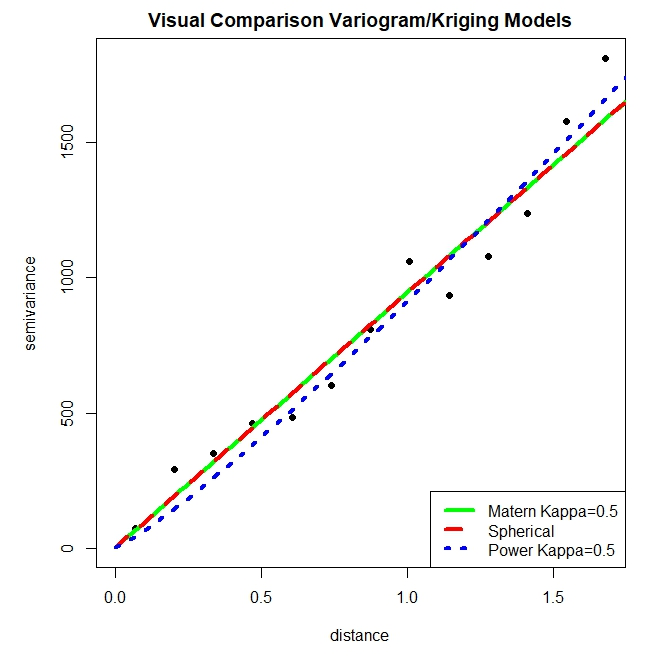

**Fig 5: Visual Comparison Variogram/Kriging Models**

We see how the models are not very dissimilar and seem to fit reasonably well the sample variogram, even tough there are datapoints that they are not able to capture.

Table 1: Variogram Models Comparison

| Model | SSQ | MAE |
| --- | --- | --- |
| Matern Kappa=0.5 | 43033039 | 11.33191 |
| Spherical | 43013148 | 11.33191 |
| Power Kappa=0.5 | 36536081 | 20.73802 |

In table 1 we can see the comparison between the fitted models based on sum of squares, and mean absolute errors.

We see that the best models in terms of minimizing sum of squares is the model with Power covariance function, but its mean absolute error is quite high and also the residuals don’t provide confirmation of goodness of fit.

The best model seems to be the second, with spherical covariance function, especially since its residuals, from cross-validation done on the training set, shown in figure 6, are reasonably good.They are approximately normal, even tough the model seems to be unable to estimate the data values for precipitations over 120mm.

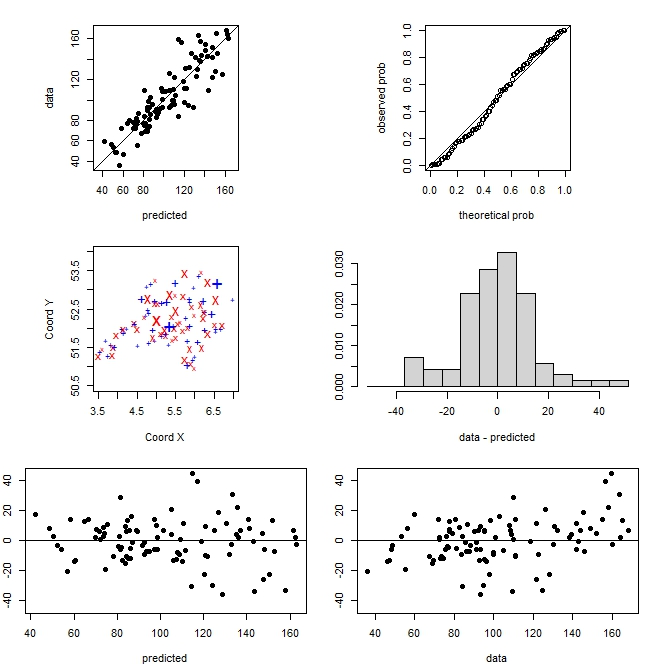

**Fig 6: Residuals from Cross Validation Best Variogram Model**

Changing further the covariance functions, and also the mean function could help improve the model fit and produce better residuals.

## 1.D

In part D we want to use Gaussian process model fitted using maximum likelihood, to estimate the parameters.

We will use for optimization the same initial values that we defined previously and the fixed nugget, since we have seen in the previous part that there was a small nugget effect in the data.

The models will all be fitted on the training dataset, that includes 95 stations.

```r
model_lik_1<- likfit(precip_data_train_geo, ini.cov.pars =ini_values_krig,trend="1st",lik.method="ML",cov.model="matern",fix.nugget=T,nugget=2)
```

The first model includes also a linear trend for the mean function, since we have seen the presence of such trend in the initial data analysis.

The covariance function used in the first attempt to model is the Matern.

We then change the covariance function, using the spherical in the second model, leaving the other assumptions unchanged.

```r
model_lik_2<- likfit(precip_data_train_geo, ini.cov.pars =ini_values_krig,trend="1st",lik.method="ML",cov.model="spherical",fix.nugget=T,nugget=2)
```

Since there are many options in terms covariance models to be used, and relative smoothness parameter kappa, we define a function that loops over the different covariance functions, and kappa values from 0.5 to 2.

The function calculates the AIC and log likelihood for each model and returns the model with the lowest AIC and highest log likelihood, which should indicate a better fit and therefore considered a better model.

```r
cov_models <- c("matern", "exponential", "gaussian", "spherical", "circular",
                "cubic", "wave", "powered.exponential", "cauchy",  "gneiting")
kappa_values <- c(0.5, 1, 1.5, 2)

estimate_model <- function(data, cov_models, kappa_values = NULL) {
  best_model <- NULL
  best_aic <- Inf
  best_log_likelihood <- -Inf

  for (cov_model in cov_models) {
    for (kappa in kappa_values) {
      # Estimate model parameters
      model <- likfit(data, ini.cov.pars = ini_values_krig, trend = "1st",
                      lik.method = "REML", cov.model = cov_model, fix.nugget = TRUE,
                      nugget = 2, kappa = kappa)

      # Calculate AIC
      aic <- AIC(model)

      # Calculate log-likelihood
      log_likelihood <- logLik(model)

      # Update best model
      if (aic < best_aic || (aic == best_aic && log_likelihood > best_log_likelihood)) {
        best_model <- model
        best_aic <- aic
        best_log_likelihood <- log_likelihood
        best_cov_model <- cov_model
        best_kappa <- kappa
      }
    }
  }

  cat("Best Covariance Model:", best_cov_model, "\n")
  cat("Best Kappa Value:", best_kappa, "\n")
  cat("\n")

  return(best_model)
}



# Estimate the best model
best_model <- estimate_model(precip_data_train_geo, cov_models, kappa_values)
```

[output not shown]

The model with the lowest AIC and highest Log likelihood is the model with covariance function defined with powered exponential and kappa equal to 0.5.

We will therefore fit this model and assess its goodness.

```r
model_lik_best<- likfit(precip_data_train_geo, ini.cov.pars =ini_values_krig,trend="1st",lik.method="REML",cov.model="powered.exponential",fix.nugget=T,nugget=2,kappa=0.5)
```

We compare the fitted models based on AIC ,Log Likelihood and Mean Absolute Error.

Table 2: Gp Models estimated with MLE Comparison

| Model | AIC | LogLikelihood | MAE |
| --- | --- | --- | --- |
| Matern GP | 814.4734 | -402.2367 | 11.33919 |
| Spherical GP | 814.0792 | -402.0396 | 11.30467 |
| Powered Exponential GP Kappa=0.5 | 760.3443 | -375.1722 | 10.54732 |

From table 2 we see the confirmation that model with powered exponential covariance function and kappa equal to 0.5 is the best.

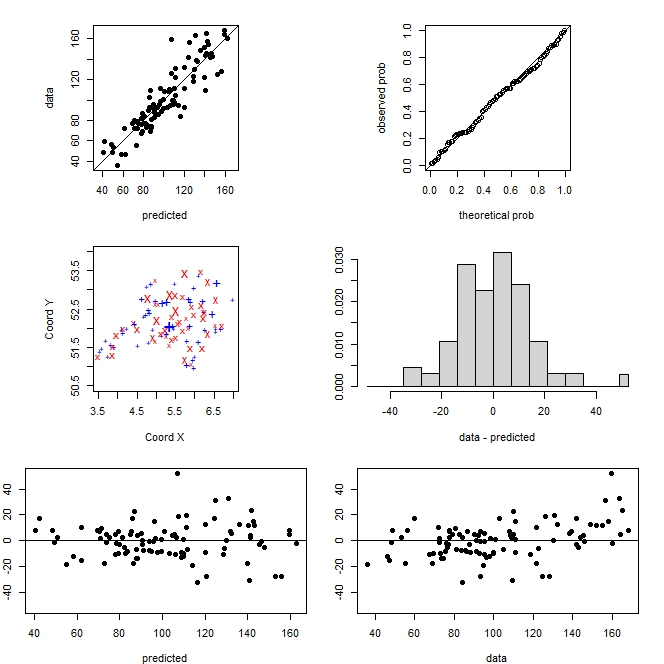

**Fig 7: Residuals from Cross Validation Best GP MLE Model**

The residuals appear reasonably normal, with approximately constant variance, the spatial residuals are not perfect, especially the negative residuals and the model still seems to be unable to capture the pattern in some datapoints.

From figure 7 we see how the best Gaussian Process Model with parameters fitted Maximum Likelihood, that include also a linear trend in the mean, is a better fit than the best Variogram Model.

## 1.E

In this part of question 1 we will use the Bayesian Approach to estimate the parameters.

The model is set so to have a powered exponential covariance function, since this was the covariance function of the best Gaussian Process estimated with MLE.

In the model control we also define a mean function with linear trend.

We define the prior for the correlation length parameter, based on the estimated values for this parameters from the previous model, therefore the discrete prior will have a range from 0.2 to 1.1.

For the nugget we define a range from 0 to 2, since we considered the nugget effect very small but present. We set the bins so that we optimize the trade-off between precision and efficiency of running and producing output from the model, since the model has to sample to produce the posterior distribution for the parameters of interest.

The priors for both the correlation length and the nugget parameters are set as reciprocal , so that the prior belief is for these parameters is to have a higher probability of taking smaller values and lower of taking larger values.

Since we have limited knowledge about the parameters and we consider their range to be comprised by small values, based on the previous analysis, this seems a reasonable, even if not completely precise, choice.

```r
bayes_precip <- krige.bayes(
  geodata = precip_data_train_geo,
  loc = ex.grid,
  model = model.control(
    trend.d = "1st",
    trend.l = "1st",
    cov.model = "powered.exponential"
  ),
  prior = prior.control(
    phi.discrete = seq(0.2, 1.1, l = 20),
    phi.prior = "reciprocal",
    tausq.rel.prior = "reciprocal",
    tausq.rel.discrete = seq(0, 2, l = 50)
  )
)
```

```r
# extract params summary
bayes_precip$posterior$phi$summary
```

```
 mean    median      mode
```

0.4761400 0.3894737 0.2000000

The median and mean value for the correlation parameter are around 0.4.

```r
bayes_precip$posterior$sigmasq$summary
```

```
 mean    median mode.cond
```

305.7760 297.2260 275.4761

The median and mean for the partial sill parameter are around 300.

```r
bayes_precip$posterior$tausq.rel$summary
```

```
  mean     median       mode
```

0.15743635 0.08163265 0.04081633

The values from the posterior distribution for the nugget are on average very small.

These values are similar to the values of the parameters estimated from the best Gaussian Process model in part D.

```r
model_lik_best$parameters.summary
```

```
##            status     values
## beta0   estimated -2290.7051
## beta1   estimated   -13.5045
## beta2   estimated    47.2291
## tausq       fixed     2.0000
## sigmasq estimated   285.1702
## phi     estimated     0.1875
## kappa       fixed     0.5000
## psiA        fixed     0.0000
## psiR        fixed     1.0000
## lambda      fixed     1.0000
```

We see how sampling from a reduced sample and using non-informative priors made the parameter estimation very similar to the MLE model, since the likelihood had far higher impact on the posterior distribution than the priors.

# Question 2

## 2.A

In question 2 we study the global surface temperature anomaly.

The complete time series contains monthly data, spanning from 1850 to 2023.

The anomaly is calculated with respect to the mean of global surface temperature for the period 1951-1980.

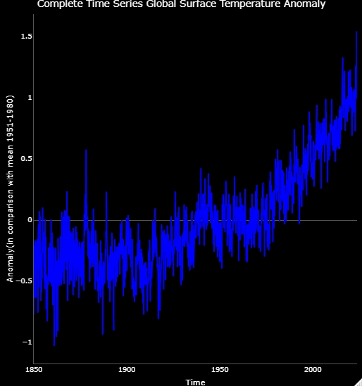

**Fig 8 : Complete Time Series Global Surface Anomaly**

From fig 8 we see that the time series seems to exhibit relatively stationary behavior from 1850 to 1930, afterwards there is an upward trend,with steeper slope in the last years. Upward trend that shows indeed increase in global surface temperature, and confirmation of global warming.

## 2.B

To study and model the data, we limit the dataset under analysis to data from 1990 onward.

The time series from 1990 seems to be not stationary.

We check this using the Augmented Dickey-Fuller and the KPSS tests.

```r
print(p_value, digits = 16)
```

```
## [1] 0.01
```

```r
print(p_value_kpss, digits=16)
```

```
## [1] 0.01
```

The null hypothesis is of stationarity for the first test and the opposite for the KPSS test.

The small p-values indicate rejection of the null for both tests, and mixing results in terms of proved stationarity of the time series.

Since we still presume non-stationarity we will calculate the difference of the time series. This differenced series shows much more stationary and stable behaviour. Assuring stationarity of the time series is a necessary step to fit ARIMA and ARMA models.

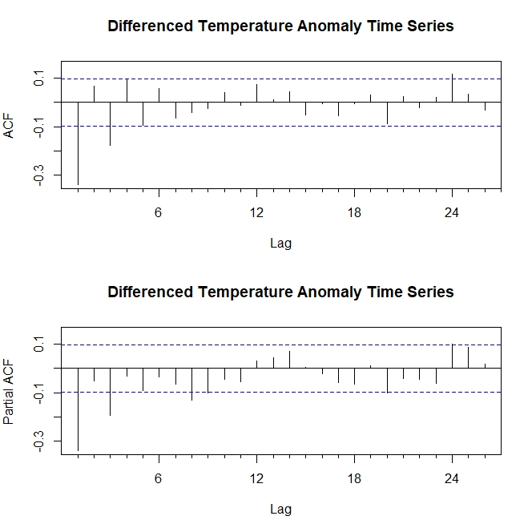

**Fig 9: Acf and Pacf Differenced Monthly Anomaly**

From figure 9 ,that shows the ACF and PACF of the differenced time series, we see significant lags 1 and 3.

After having differenced the time series to make it stationary, we will fit Arima and then ARMA models, without seasonal components, and compare them based on AIC and Log Likelihood values. The model with the best metrics and reasonable residuals will be chosen for forecasting out of the sample.

We first use auto.arima that automatically searches for the best Arima model, we set the maximum difference equal to 1, since taking the first difference of the original time series was enough to make it stationary.

```r
arima_auto <- auto.arima(surf_temp_recent_ts,max.d=1, seasonal = FALSE,include.mean=T)
```

Having noticed significant spikes at lag 1 and 3 for the ACF and PACF , shown in figure 9 , of the differenced time series, we will fit first ARIMA(3,1,3) with drift included.

```r
arima_2<-Arima(surf_temp_recent_ts,order=c(3,1,3),include.drift=T)
```

Then an ARIMA(1,1,3)

```r
arima_3<-Arima(surf_temp_recent_ts,order=c(1,1,3),include.drift=T)
```

And also an ARIMA(3,1,1)

```r
arima_4<-Arima(surf_temp_recent_ts,order=c(3,1,1),include.drift=T)
```

Finally, since the most significant lag in the ACF and PACF was the first one we will try fitting also an ARIMA(1,1,1).

```r
arima_5<-Arima(surf_temp_recent_ts,order=c(1,1,1),include.drift=T)
```

The Arima models are fitted on the original time series, and the model definition applies the first difference, since d=1.

Then we fit ARMA models. In this case the models are fitted to the differenced time series.

The first ARMA is defined with 1 autoregressive and 1 moving average term since the most significant lag in the ACF and PACF was lag 1.

```r
arma_1 <- Arima(diff(surf_temp_recent_ts),order=c(1,0,1),include.drift=T)
```

Since it is not always possible to assess the correct moving average and autoregressive terms for an ARMA model just by analyzing the ACF and Pacf, we want to fit models with different terms to see if the fit can be improved.

We fit an ARMA(2,0,1).

```r
arma_2 <- Arima(diff(surf_temp_recent_ts),order=c(2,0,1))
```

And then,an ARMA(4,0,3), to see if adding parameters can improve the fit, even if this can lead to potential overfitting.

```r
 arma_3 <- Arima(diff(surf_temp_recent_ts),order=c(4,0,3))
```

We now compare the ARIMA and ARMA models to decide which one is the best.

Table 3: Arima and ARMA Models Comparison

| Model | AIC | LogLikelihood |
| --- | --- | --- |
| ARIMA 1,1,4 | -625.6510 | 319.8255 |
| ARIMA 3,1,3 | -638.6973 | 327.3487 |
| ARIMA 1,1,3 | -625.5603 | 318.7802 |
| ARIMA 3,1,1 | -637.6512 | 324.8256 |
| ARIMA 1,1,1 | -620.3343 | 314.1672 |
| ARMA 1,1 | -619.4432 | 314.7216 |
| ARMA 2,1 | -638.4884 | 324.2442 |
| ARMA 4,3 | -637.1080 | 327.5540 |

From table 3 we see how ARIMA(3,1,3) , Arima(3,1,1) and ARMA(2,1) are very similar in terms of AIC.

We will therefore choose the ARIMA(3,1,3), since its residuals are better, even tough the choice could be also for the other models to reduce complexity.

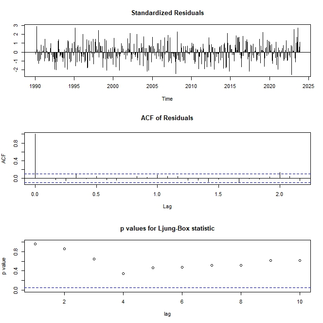

**Fig 10 : Residuals Best Arima Model Part B**

The residuals of the best model show no clear pattern, and limited autocorrelation, validating the choice of the model.

## 2.C

In Part C we consider the same dataset used for part B, but we aggregate the original data , using monthly means, in quarterly data.

Taking the first difference makes the time series more stationary.

The analysis of the differenced time series with seasonality at lag 4(since we use quarterly data), shows lack of stationarity.

The ACF and PACF of the differenced quarterly time series, shows no clear indication of which terms should be included in the first SARIMA model ,therefore we will start with a simple model that has 1 moving average term both in the non-seasonal and seasonal part.

The full model is a SARIMA(0,1,1, 0,1,1).

The model includes a seasonal difference to account for the lack of stationarity in the differenced time series with seasonality at lag 4.

```r
model_seas <- Arima(surf_temp_quart_ts,
                    order = c(0, 1, 1),
                    seasonal = list(order = c(0, 1, 1),
                                    period = 4))
```

We compare this model with the choice of auto.arima with seasonal component, which gives a SARIMA(0,1,0, 1,0,1) not differencing on the seasonal part.

```r
auto_seas<-auto.arima(surf_temp_quart_ts,seasonal=T)
```

We then create a function that loops over different autoregressive and moving average terms for both the not-seasonal and the seasonal part.

The function considers 1 difference for both parts, based on the reasons explained previously, and tries to find the model with the lowest AIC.

```r
d <- 1
D <-1
s <- 4
results <- data.frame()

for(p in 1:4) {
  for(q in 1:4) {
    for(P in 1:4) {
      for(Q in 1:4) {
        if(p + d + q + P + D + Q <= 12) {
          model <- Arima(surf_temp_quart_ts, order = c(p-1, d, q-1),include.drift =T, seasonal = list(order = c(P-1, D, Q-1), period = s))
          test <- Box.test(residuals(model), lag = log(length(residuals(model))))
          sse <- sum(residuals(model)^2)
          results <- rbind(results, c(p-1, q-1, P-1, Q-1, model$aic, sse, test$p.value))
        }
      }
    }
  }
}

colnames(results) <- c("p", "q", "P", "Q", "AIC", "SSE", "BoxTestPValue")
results <- as.data.frame(results)
results$AIC <- as.numeric(as.character(results$AIC))
results$SSE <- as.numeric(as.character(results$SSE))
results$BoxTestPValue <- as.numeric(as.character(results$BoxTestPValue))


best_model <- results[which.min(results$AIC),]

cat("Best model parameters:\n")
```

```
## Best model parameters:
```

```r
print(best_model)
```

```
##    p q P Q      AIC      SSE BoxTestPValue
## 71 1 1 0 1 -215.317 1.269664      0.863548
```

The best model seems to be a SARIMA(1,1,1) with seasonal part (0,1,1), and will be therefore fitted.

```r
model_seas_2 <- Arima(surf_temp_quart_ts,
                    order = c(1, 1, 1),
                    seasonal = list(order = c(0, 1, 1),period = 4))
```

Now we also fit ARIMA and ARMA models ,with no seasonal component, to see if they can be good choices.

```r
# empty df to store results
results <- data.frame()

# Loop through different combinations of p, d, and q values
for(d in c(0, 1)) {
  for(p in 1:5) {
    for(q in 1:5) {

      if(p + d + q <= 10) {

        if(d == 0) {
          model <- Arima(diff(surf_temp_quart_ts), order = c(p-1, d, q-1), include.drift = TRUE)
        } else {
          model <- Arima(surf_temp_quart_ts, order = c(p-1, d, q-1), include.drift = TRUE)
        }


        results <- rbind(results, c(p-1, d, q-1, AIC(model)))
      }
    }
  }
}


colnames(results) <- c("p", "d", "q", "AIC")
results$AIC <- as.numeric(results$AIC)

# Select model with the lowest AIC
best_model <- results[which.min(results$AIC),]

#  best model
print(best_model)
```

```
##    p d q       AIC
## 19 3 0 3 -236.2819
```

The model with lowest AIC value according to our function, is an ARMA(3,3).

We wil fit this model on the differenced time series.

```r
best_arma <- Arima(diff(surf_temp_quart_ts), order = c(3, 0, 3))
```

This model presents coefficient that are all significant.

Now we compare the SARIMA and the best ARMA model, considering AIC and Log Likelihood.

Table 4: SARIMA and ARMA Models Comparison

| Model | AIC | LogLikelihood |
| --- | --- | --- |
| SARIMA 0,1,1 0,1,1 | -205.1917 | 105.5959 |
| SARIMA 0,1,0 1,0,1 | -217.9009 | 111.9504 |
| SARIMA 1,1,1 0,1,1 | -215.3170 | 111.6585 |
| ARMA 3,0,3 | -235.8935 | 125.9468 |

The best model is the ARMA (3,3) according to table 4.

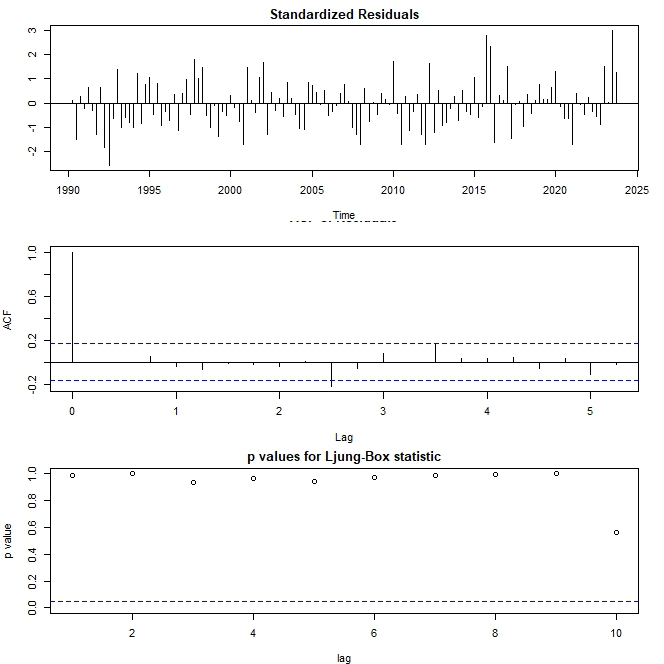

**Fig 11: Residuals Best Model Quarterly Data**

The residuals of the best Arma model, are not autocorrelated, even tough, as expected, there is some seasonal variability that the model is not able to address.

Nonetheless we will choose ARMA 3,3 as the best model for part C, since it has the best metrics and reasonably good residuals.

## 2.D

In part D we fit two Dynamic Linear Models with linear trend and respectively, quarterly and monthly seasonality.

The first one will be fit on the quarterly time series.

For the first model we have to estimate the variance of the observation noise, and the variances of the state equation for both the linear and the seasonal part.

We create a function to define these parameters and a matrix with zeros, elsewhere. We will then estimate the parameters using Maximum Likelihood.

The initial values for the 3 parameters will be set as 0.

```r
  Dlm_lin_quart <- function(x) {
    dlmModPoly(order = 2, dV = exp(x[1]), dW = c(0, exp(x[2]))) +
      dlmModSeas(frequency = 4, dV = 0, dW = c(exp(x[3]), rep(0,2)))
  }

Mle_lin_quart <- dlmMLE(surf_temp_quart_ts, parm = c(0,0,0), build =Dlm_lin_quart)
```

We check that convergence has been reached.

```r
# check convergence
Mle_lin_quart$convergence
```

```
## [1] 0
```

We then apply the Kalman filter to the fitted model. This will update and filter the estimate of the state variables at each time step, based on new observations.

```r
# Kalman filter
fitted_model_lin_quart <-Dlm_lin_quart(Mle_lin_quart$par)
surf_temp_quart_lin <- dlmFilter(surf_temp_quart_ts, mod = fitted_model_lin_quart)
```

We then fit a Dlm model on the monthly time series.

This model will have monthly seasonality and linear trend.

The parameters to estimate are still the 3 variances, for which the initial values will be set as 0.

```r
Dlm_lin_monthly <- function(x) {
  dlmModPoly(order = 2, dV = exp(x[1]), dW = c(0, exp(x[2]))) +
    dlmModSeas(frequency = 12, dV = 0, dW = c(exp(x[3]), rep(0, 10)))
}

# Initial params
initial_params <- c(0, 0, 0)

# Fit the model with Mle
Mle_lin_monthly <- dlmMLE(surf_temp_recent_ts, parm = initial_params, build = Dlm_lin_monthly)
```

We check also in this case convergence.

```r
Mle_lin_monthly$convergence
```

```
## [1] 0
```

And finally we apply the Kalman filter to the fitted model.

```r
# Kalman filter
fitted_model_lin_monthly <- Dlm_lin_monthly(Mle_lin_monthly$par)
lin_monthly_surf<- dlmFilter(surf_temp_recent_ts, mod=fitted_model_lin_monthly )
```

We now compare the two DLMs based on Mean Squared Error, Mean Absolute Deviation,Mean Absolute Percentage Error,all calculated on the models residuals. Furthermore we make the comparison based also on Log Likelihood and especially AIC.

Table 5: DLM Models Comparison

|  | MSE | MAD | MAPE | logLik | AIC | NumParam |
| --- | --- | --- | --- | --- | --- | --- |
| Linear Quarterly | 0.0198828 | 0.1113161 | 0.2118730 | -166.3467 | 338.6934 | 3 |
| Linear Monthly | 0.0172669 | 0.1033388 | 0.0100506 | 518.1991 | -1030.3982 | 3 |

We can clearly see how the Dlm with linear trend and monthly seasonal part performs better in terms of all the metrics and it is less biased.

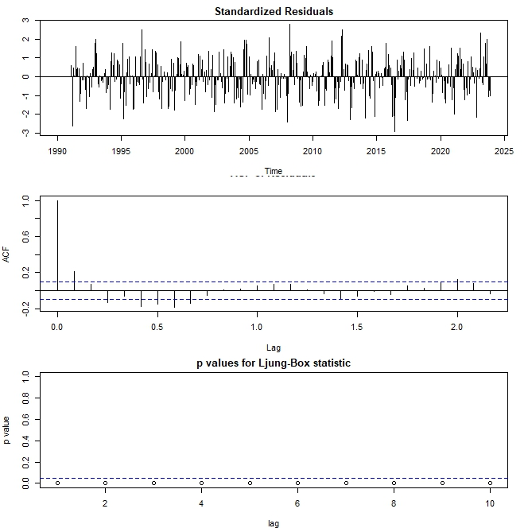

**Fig 12: Residuals Best DLM**

The residuals of the best model seem autocorrelated and don’t explain all the variability in the data, but the same was true for the residuals of the other DLM.

Therefore considering that the Linear Monthly DLM performed better in terms of AIC and other metrics, it will be considered the best model for this part.

## 2.E

In this part we will forecast the global surface temperature anomaly for 2024 using the best models chosen.

```r
# forecast best model part b
best_mod_b_fore= forecast( arima_2, h = 12)
# forecast best model part c , h=3 since fitted on quarterly data
arima_best_c_fore<-forecast(arima_best_c,h=3)
# best model from part D forecast
best_dlm_forecast <- dlmForecast(lin_monthly_surf, nAhead =12)
```

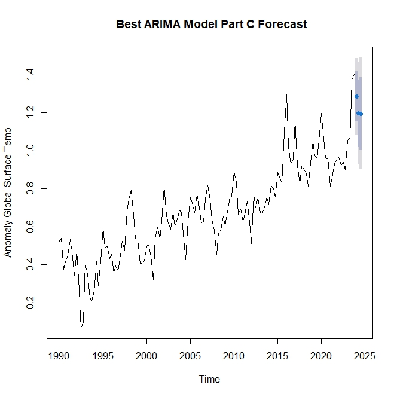

**Fig 13: Forecast Best Arima Part C**

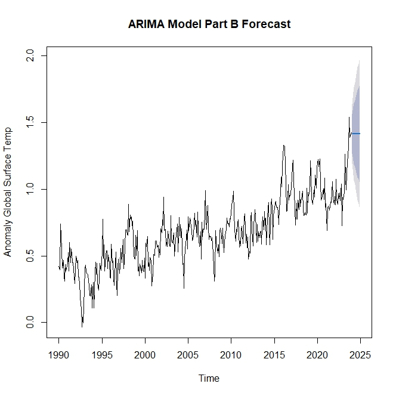

**Fig 14: Forecast Best ARIMA Part B**

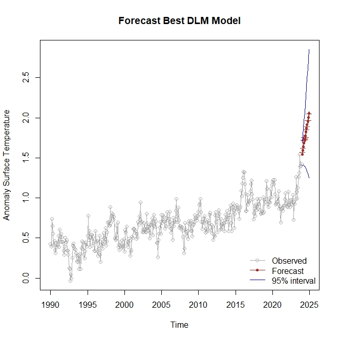

**Figure 15: Forecast Best DLM Model**

We see from figures 13-15, how, while, the Arima models predict a decrease or a constant level in anomaly for global surface temperature, the best Dlm model predicts a continuation of the upward trend, so it is close to the actual trend of the studied time series.

It is important to remember how the best way to really assess the forecasts produced by these models would be to compare them with the actual values for 2024, which we don’t have.

# Question 3

## 3.A

In this question we will model the maximum daily temperatures for some weather stations in UK for 2022.

We first analyze the weather stations in terms of their presence in the UK territory and based on their elevation.

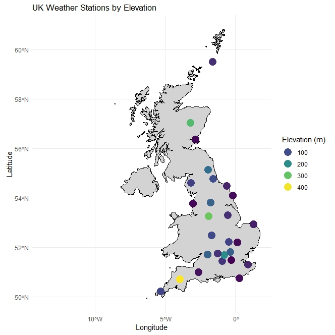

**Fig 16 : UK Weather Stations by Elevation**

The stations present similar elevation, excluding a couple of outliers.

They are concentrated in the South-East of UK, with the exception being Fair Isle, in Scotland, and other in the middle of the UK territory.

Since the elevation doesn’t differ much, the main elements for the spatial analysis will be the longitude and latitude coordinates.

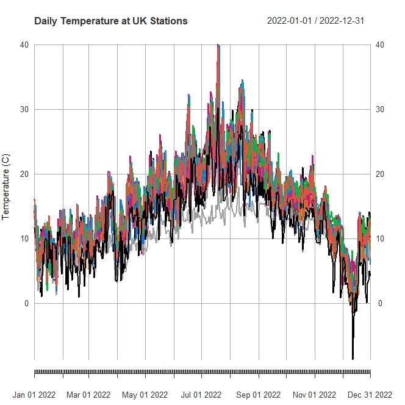

**Fig 17: Time Series of Max Temperature 2022 UK Stations**

The time series of maximum temperatures, shown in figure 17, clearly displays the expected pattern in maximum daily temperature, with increase from January and peak in July and then decrease until the end of the year, typical seasonal variation.

There are some differences between the stations, since some are more in the North of UK, like Fair Isle, but overall they follow the same pattern.

It is clear from this plot how it won’t be useful to analyze the maximum temperature using data from periods far apart from each other.

## 3.B

In this part we want to fit a Gaussian Process to predict the maximum temperature for 3 stations on the 24th of July.

We first merge the spatial dataset with the dataset containing maximum daily temperatures for the stations.

We then select and keep only data until the 24th of July, to avoid look-ahead bias, and since we want to forecast for July, we subset the dataset to contain data only from the 23th of June until the 23th of July.

We exclude the 3 stations we want to predict for from the training dataset.

We fit a Gaussian Regression process to the training dataset.

We use the squared exponential kernel since we want to model a non linear complex relationship.

We also specify the initial value for the noise variance parameter, based on the variance in the observed temperatures in the training set.

```r
# Predictor and response
X <- train_data_gp_clean[, c("station_longitude", "station_latitude", "station_elevation")]
y <- train_data_gp_clean$temperature


gp_model <- gausspr(X, y, kernel = "rbfdot", fit.method = "mle",var=25)
```

We then predict the temperature for the 24th of July for the 3 stations using the fitted model.

```r
predicted_temperatures <- predict(gp_model, test_data_try)
```

```r
print(predicted_df)
```

```
##      Station Predicted_Temperatures
## 1 Wallington               25.00583
## 2    Reading               22.44965
## 3     Whitby               21.75192
```

```r
actual_temperatures
```

```
## [1] 26.3 24.0 18.9
```

We see how the predictions are not completely accurate, but we have to consider how there is variability in these weather forecasts, especially since the model has been trained and has used as predictors coordinates of stations that might be not close to the 3 for which we made the forecast.

[1] “MAPE: 8.82338053877135” [1] “MAE: 1.89881545933876” [1] “MSE: 4.07064416128734” [1] “RMSE: 2.0175837433146”

We see how the forecasted temperatures are biased, and present errors of approximately 2 degrees.

## 3.D

In this part we want to forecast maximum daily temperature for Fair Isle for the period 1-5 May and for Bridlington for the period 31th October-4th of November.

For the first task we will first analyze the monthly averages maximum temperatures for the Fair Isle station,.

```r
fair_isle_monthly <- apply.monthly(fair_isle_xts, mean)
fair_isle_monthly
```

```
##            Max_Daily_Temp
## 2022-01-31       8.025806
## 2022-02-28       6.532143
## 2022-03-31       7.796774
## 2022-04-30       7.790000
## 2022-05-31      10.796774
## 2022-06-30      12.960000
## 2022-07-31      14.048387
## 2022-08-31      14.464516
## 2022-09-30      13.550000
## 2022-10-31      11.916129
## 2022-11-30      10.693333
## 2022-12-31       6.564516
```

We see that the monthly temperatures differ a lot, as was already possible to see from the daily time series over 2022.

But there is not a huge difference in the means from January to April.

We will subset the 2022 time series and only consider data until the 30th of April , since this would have been the data available at the time of the forecast in 2022, and we don’t want to introduce look-ahead bias by using data that wouldn’t have been available.

The plot of the time series January- April shows no stationarity.

Since we assume that the data closer to the beginning of May are gonna be similar the data from the closest period, that is April, we will fit the first model considering only April daily data.

[figure not shown]

**Fig 18: ACF and PACF Differenced TS April Fair Isle**

From figure 18 we see significant lags 1 and 3 in the PACF and none for the ACF.

We will therefore start fitting an ARIMA(3,1,0), with no drift, since in the phase of model study the model was estimated with drift, and this resulted to be non significant.

```r
mod_arima_fair <- Arima(fair_isle_train, order = c(3, 1, 0))
```

Then we want to also see, considering that the monthly temperatures were not extremely different from January to April, if a model estimated using more data could produce better results.

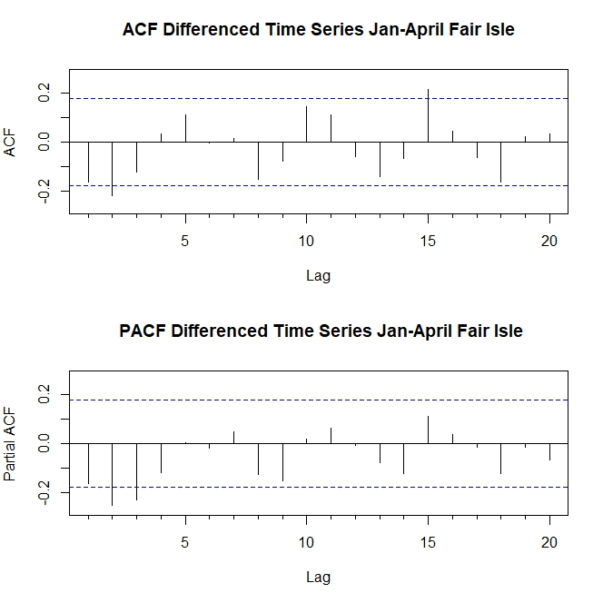

**Fig 19 : Acf and Pacf Differenced TS Jan-Apr Fair Isle**

We see from figure 19 significant spikes at lag 2 for both the ACF and PACF of the differenced series January-April and therefore we try an ARIMA(2,1,2) fitted on these 4 months.

```r
arima_fair_4<- Arima(fair_isle_xts_subset , order = c(2, 1, 2))
```

Since AR(1), AR(2) and also MA(2) terms resulted in being non significant, we want to try to fit an ARIMA(0,1,1) on the same data.

```r
arima_fair_2<- Arima(fair_isle_xts_subset , order = c(0, 1, 1))
```

Table 6: ARIMA Models Comparison Fair Isle

| Model | AIC | LogLikelihood |
| --- | --- | --- |
| ARIMA 3,1,0 fitted on 1 Month | 101.8963 | -46.94816 |
| ARIMA 2,1,2 fitted on 4 Months | 400.2908 | -195.14542 |
| ARIMA 0,1,1 fitted on 4 Months | 407.1966 | -201.59832 |

We compare the 3 fitted models in terms of AIC and Log Likelihood and we see that the model fitted on the April dataset seems to be the best.

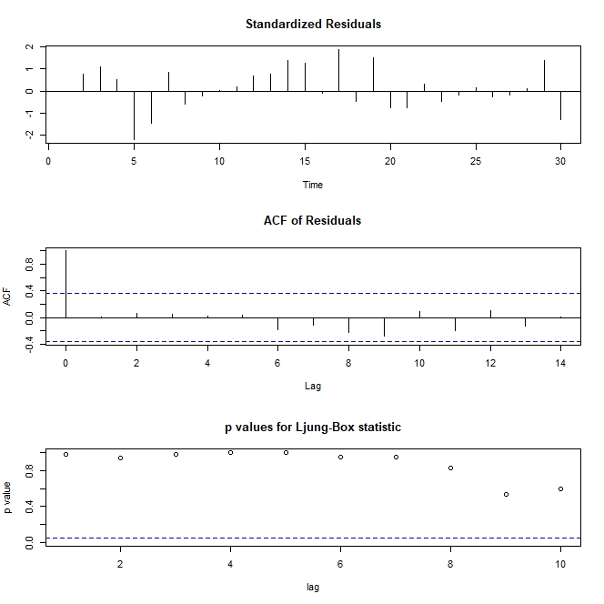

**Fig 20 : Residuals Best Arima Model Fair Isle**

The residuals confirm a good model fitting, and therefore we will use this model for forecasting.

```r
arima_fair_fore= forecast(mod_arima_fair, h = 5)
arima_fair_fore
```

```
##    Point Forecast    Lo 80     Hi 80    Lo 95    Hi 95
## 31       8.051113 6.414368  9.687857 5.547928 10.55430
## 32       8.816162 6.845320 10.787004 5.802019 11.83031
## 33       9.130039 7.099099 11.160980 6.023984 12.23610
## 34       8.691833 6.574961 10.808705 5.454357 11.92931
## 35       8.521153 6.193025 10.849281 4.960589 12.08172
```

```r
may_fair <- window(fair_isle_xts, start = as.Date("2022-05-01"), end = as.Date("2022-05-05"))
actuals_fair<-may_fair$Max_Daily_Temp
actuals_fair
```

```
##            Max_Daily_Temp
## 2022-05-01            8.5
## 2022-05-02            8.0
## 2022-05-03            8.7
## 2022-05-04           10.7
## 2022-05-05           10.2
```

```
##                     ME     RMSE      MAE        MPE     MAPE      MASE
## Training set 0.1670655 1.188970 0.928821 -0.1202102 12.92810 0.8661032
## Test set     0.5779401 1.257284 1.076421  5.0726451 11.13065 1.0037362
##                     ACF1
## Training set 0.005668729
## Test set              NA
```

The model is able to forecast quite well the first 3 days, but the forecast becomes worse for the last 2.

Now we want to forecast and model the data for the other station.

We reason in the same way used for the other station, even tough we have data until the end of 2022, we will use data that would have been available if we made the forecast in 2022, that is until 30th of October, so to avoid bias.

```r
bridlington_xts_subset <- window(bridlington_xts, end = as.Date("2022-10-30"))
```

```r
bridlington_monthly_subset <- apply.monthly(bridlington_xts_subset, mean)

bridlington_monthly_subset
```

```
##            Max_Daily_Temp
## 2022-01-31       8.116129
## 2022-02-28       9.932143
## 2022-03-31      10.245161
## 2022-04-30      12.193333
## 2022-05-31      16.477419
## 2022-06-30      18.953333
## 2022-07-31      21.087097
## 2022-08-31      22.251613
## 2022-09-30      17.766667
## 2022-10-30      16.230000
```

The monthly averages differ from January to October.

We could use data from May but this would create a non continuous time series, therefore we use data from October for fitting the first model, closer to the period that we want to forecast for.

We take the first difference of this October dataset to make it stationary and we analyze the ACF and PACF.

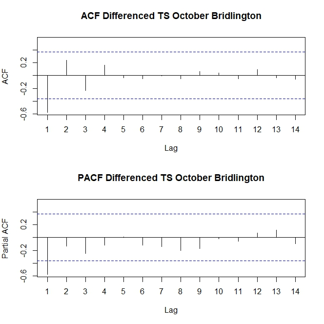

**Fig 21 : ACF and PACF Differenced Ts October Bridlington**

We see significant lags 1 for both ACF and PACF, and therefore decide to fit an ARIMA(1,1,1) to the October data.

```r
arima_bridlington_1<-Arima(bridlington_1m ,order = c(1, 1, 1))
```

We then try to consider to use a dataset that contains temperatures from the 18th of September to the end of October to fit a model.

We take the first difference to make this new time series stationary, and studying the ACF and PACF of the differenced series we notice significant lag 1 for both.

Therefore we fit an ARIMA(1,1,1) to the this new data.

```r
bridlington_2m <- window(bridlington_xts,start=as.Date("2022-09-18"),end = as.Date("2022-10-30"))

arima_bridl_2<-Arima(bridlington_2m ,order = c(1, 1, 1))
```

We compare the two models fitted for Bridlington, using AIC and Log Likelihood.

```r
kable(model_comparison_bridl, format = "html", caption = " Table 7:  ARIMA Models  Comparison Bridlington") %>%
  kable_styling(bootstrap_options = c("striped", "hover", "condensed"), full_width = F)
```

Table 7: ARIMA Models Comparison Bridlington

| Model | AIC | LogLikelihood |
| --- | --- | --- |
| ARIMA 1,1,1 fitted on 30 Days | 116.2175 | -55.10876 |
| ARIMA 1,1,1 fitted on 43 Days | 174.7960 | -84.39802 |

We see from table 7 how the model fitted on the shorter period has a better AIC and Log Likelihood.

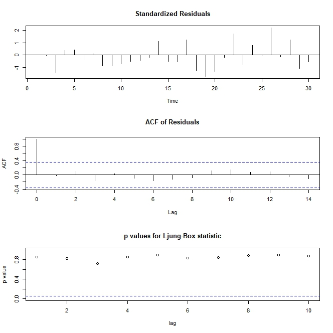

Fig 22: Residuals Best Arima Model Bridlington

The residuals validation confirms that this model is better, since they are less correlated than for the other ARIMA, even tough there is some homoskedasticity in the standardized residuals.

We forecast using the ARIMA(1,1,1) fitted on the shorter period and we compare the forecast with the actual values for 31th October-4 November.

```r
arima_brid_fore= forecast(arima_bridlington_1, h = 5)
arima_brid_fore
```

```
##    Point Forecast    Lo 80    Hi 80    Lo 95    Hi 95
## 31       16.07596 13.95716 18.19477 12.83553 19.31640
## 32       16.04525 13.87392 18.21658 12.72449 19.36602
## 33       16.04665 13.80689 18.28641 12.62123 19.47206
## 34       16.04658 13.74123 18.35193 12.52085 19.57231
## 35       16.04659 13.67742 18.41575 12.42326 19.66991
```

The forecasted temperatures perform well for the first 2 days, but are far from the actual values for the last 3 days.

```r
actuals_brid
```

```
##            Max_Daily_Temp
## 2022-10-31           14.7
## 2022-11-01           15.0
## 2022-11-02           13.2
## 2022-11-03           13.1
## 2022-11-04           12.9
```

```r
# Comparison with actual values
accuracy_metrics_brid <- accuracy(arima_brid_fore, actuals_brid)
accuracy_metrics_brid
```

```
##                      ME     RMSE      MAE        MPE      MAPE      MASE
## Training set -0.2466953 1.568471 1.267715  -2.281877  7.945536 0.7974782
## Test set     -2.2722057 2.436086 2.272206 -16.955853 16.955853 1.4293702
##                     ACF1
## Training set -0.03247673
## Test set              NA
```

The MAPE shows a difference of 17% between the forecasted values and the actual values, and there is overestimation, especially in the last 3 days for the forecasts.

It is worth remembering that the further the forecasts from an ARIMA model go the more variance and less precision will be, and the value will tend towards the mean.

# References

[output not shown]

# AI Declaration

## Statement of Acknowledgement

I acknowledge the use of ChatGpt,https://chat.openai.com/, to generate materials for background research and independent study. I confirm that no content generated by AI has been presented as my own work. I acknowledge the use of ChatGpt to refine writing/improve grammar within my final assessment. I confirm that no content generated by AI has been presented as my own work.